# Krzywe ROC i modele zespołowe

Adam Michalski

#Zadanie 1

Na początek wczytujemy dane oraz tworzymy ramki danych z kolumną binarną informującą, czy irys jest przedstawicielem konkretnego gatunku:

```r
library(datasets)
data(iris)
iris$is_Setosa <- ifelse(iris$Species == "setosa", 1, 0)
iris$is_Versicolor <- ifelse(iris$Species == "versicolor", 1, 0)
iris$is_Virginica <- ifelse(iris$Species == "virginica", 1, 0)

data_is_Setosa <- subset(iris, select = c(Sepal.Length, Sepal.Width, is_Setosa))
data_is_Versicolor <- subset(iris, select = c(Sepal.Length, Sepal.Width, is_Versicolor))
data_is_Virginica <- subset(iris, select = c(Sepal.Length, Sepal.Width, is_Virginica))

summary(data_is_Setosa)
```

```
##   Sepal.Length    Sepal.Width      is_Setosa
##  Min.   :4.300   Min.   :2.000   Min.   :0.0000
##  1st Qu.:5.100   1st Qu.:2.800   1st Qu.:0.0000
##  Median :5.800   Median :3.000   Median :0.0000
##  Mean   :5.843   Mean   :3.057   Mean   :0.3333
##  3rd Qu.:6.400   3rd Qu.:3.300   3rd Qu.:1.0000
##  Max.   :7.900   Max.   :4.400   Max.   :1.0000
```

Następnie tworzymy naiwnie modele regresji logistycznej dla każdego ze zbiorów danych:

```r
reg_Setosa <- glm(is_Setosa ~ Sepal.Length + Sepal.Width, data = data_is_Setosa, family = binomial)
reg_Versicolor <- glm(is_Versicolor ~ Sepal.Length + Sepal.Width, data = data_is_Versicolor, family = binomial)
reg_Virginica <- glm(is_Virginica ~ Sepal.Length + Sepal.Width, data = data_is_Virginica, family = binomial)
summary(reg_Setosa)
```

```
##
## Call:
## glm(formula = is_Setosa ~ Sepal.Length + Sepal.Width, family = binomial,
##     data = data_is_Setosa)
##
## Coefficients:
##              Estimate Std. Error z value Pr(>|z|)
## (Intercept)     437.2   128737.9   0.003    0.997
## Sepal.Length   -163.4    45394.8  -0.004    0.997
## Sepal.Width     137.9    44846.1   0.003    0.998
##
## (Dispersion parameter for binomial family taken to be 1)
##
##     Null deviance: 1.9095e+02  on 149  degrees of freedom
## Residual deviance: 2.7060e-08  on 147  degrees of freedom
## AIC: 6
##
## Number of Fisher Scoring iterations: 25
```

```r
summary(reg_Versicolor)
```

```
##
## Call:
## glm(formula = is_Versicolor ~ Sepal.Length + Sepal.Width, family = binomial,
##     data = data_is_Versicolor)
##
## Coefficients:
##              Estimate Std. Error z value Pr(>|z|)
## (Intercept)    8.0928     2.3893   3.387 0.000707 ***
## Sepal.Length   0.1294     0.2470   0.524 0.600247
## Sepal.Width   -3.2128     0.6385  -5.032 4.85e-07 ***
## ---
## Signif. codes:  0 '***' 0.001 '**' 0.01 '*' 0.05 '.' 0.1 ' ' 1
##
## (Dispersion parameter for binomial family taken to be 1)
##
##     Null deviance: 190.95  on 149  degrees of freedom
## Residual deviance: 151.65  on 147  degrees of freedom
## AIC: 157.65
##
## Number of Fisher Scoring iterations: 5
```

```r
summary(reg_Virginica)
```

```
##
## Call:
## glm(formula = is_Virginica ~ Sepal.Length + Sepal.Width, family = binomial,
##     data = data_is_Virginica)
##
## Coefficients:
##              Estimate Std. Error z value Pr(>|z|)
## (Intercept)  -14.1836     3.1172  -4.550 5.36e-06 ***
## Sepal.Length   2.6025     0.4406   5.907 3.48e-09 ***
## Sepal.Width   -0.7458     0.6413  -1.163    0.245
## ---
## Signif. codes:  0 '***' 0.001 '**' 0.01 '*' 0.05 '.' 0.1 ' ' 1
##
## (Dispersion parameter for binomial family taken to be 1)
##
##     Null deviance: 190.95  on 149  degrees of freedom
## Residual deviance: 115.90  on 147  degrees of freedom
## AIC: 121.9
##
## Number of Fisher Scoring iterations: 6
```

Niestety model regresji logistycznej dla gatunku Setosa nie jest poprawny (okazuje się, że zmienne objaśniające pozwalają idealnie odseparować, czy dany gatunek to Setosa, czy też nie). Zastosujemy wobec tego dla gatunku Setosa regresję ridge radzącą sobie ze zbyt dobrym dopasowaniem danych.

```r
library(glmnet)
X_Setosa <- as.matrix(data_is_Setosa[, c("Sepal.Length", "Sepal.Width")])
y_Setosa <- data_is_Setosa$is_Setosa

# Fit logistic regression with L2 regularization (ridge logistic regression)
reg_Setosa <- cv.glmnet(X_Setosa, y_Setosa, family = "binomial", alpha = 0)

coef(reg_Setosa, s = "lambda.min")
```

```
## 3 x 1 sparse Matrix of class "dgCMatrix"
##                     s1
## (Intercept)   2.366757
## Sepal.Length -2.268489
## Sepal.Width   3.126432
```

```r
X_Setosa <- as.matrix(iris[, c("Sepal.Length", "Sepal.Width")])
iris$prob_Setosa <- predict(reg_Setosa, newx = X_Setosa, type = "response", s = "lambda.min")
iris$prob_Versicolor <- predict(reg_Versicolor, newdata = iris, type = "response")
iris$prob_Virginica <- predict(reg_Virginica, newdata = iris, type = "response")

# Combine predictions into final classification
iris$predicted_species <- apply(iris[, c("prob_Setosa", "prob_Versicolor", "prob_Virginica")], 1,
                                function(x) c("setosa", "versicolor", "virginica")[which.max(x)])
```

Macierz pomyłek utworzonego modelu:

```r
confusion_matrix <- table(Prediction = iris$predicted_species, Species = iris$Species)
print(confusion_matrix)
```

```
##             Species
## Prediction   setosa versicolor virginica
##   setosa         49          3         0
##   versicolor      1         33        13
##   virginica       0         14        37
```

#Zadanie 2

Na początek (jak zawsze) wczytujemy dane:

```r
library(MASS)
library(pROC)
library(naivebayes)
set.seed(123)

data(Pima.te)
data_pima <- subset(Pima.te, select = c(age, npreg, bmi, type))
summary(data_pima)
```

```
##       age            npreg             bmi         type
##  Min.   :21.00   Min.   : 0.000   Min.   :19.40   No :223
##  1st Qu.:23.00   1st Qu.: 1.000   1st Qu.:28.18   Yes:109
##  Median :27.00   Median : 2.000   Median :32.90
##  Mean   :31.32   Mean   : 3.485   Mean   :33.24
##  3rd Qu.:37.00   3rd Qu.: 5.000   3rd Qu.:37.20
##  Max.   :81.00   Max.   :17.000   Max.   :67.10
```

Przeprowadzamy podział danych na część uczącą i testową:

```r
library(caret)
set.seed(1)
train_indices <- createDataPartition(data_pima$type, p = 0.7, list = FALSE)

train_data <- data_pima[train_indices, ]
test_data <- data_pima[-train_indices, ]

cat("Class distribution in testing set:\n")
```

```
## Class distribution in testing set:
```

```r
print(table(test_data$type))
```

```
##
##  No Yes
##  66  32
```

Tworzymy model regresji logistycznej oraz jego charakterystyki liczbowe:

```r
library(caret)
threshhold <- 0.5
logistic_regression_model <- glm(type ~ age + npreg + bmi, data = train_data, family = binomial)
logistic_regression_probs <- predict(logistic_regression_model, newdata = test_data, type = "response")
logistic_regression_prediction <- ifelse(logistic_regression_probs > threshhold, "Yes", "No")
logistic_regression_prediction <- factor(logistic_regression_prediction, levels = levels(test_data$type))
summary(logistic_regression_model)
```

```
##
## Call:
## glm(formula = type ~ age + npreg + bmi, family = binomial, data = train_data)
##
## Coefficients:
##             Estimate Std. Error z value Pr(>|z|)
## (Intercept) -5.93107    0.98521  -6.020 1.74e-09 ***
## age          0.05978    0.02054   2.910  0.00361 **
## npreg        0.04895    0.06071   0.806  0.42006
## bmi          0.09237    0.02255   4.096 4.21e-05 ***
## ---
## Signif. codes:  0 '***' 0.001 '**' 0.01 '*' 0.05 '.' 0.1 ' ' 1
##
## (Dispersion parameter for binomial family taken to be 1)
##
##     Null deviance: 296.48  on 233  degrees of freedom
## Residual deviance: 251.87  on 230  degrees of freedom
## AIC: 259.87
##
## Number of Fisher Scoring iterations: 4
```

```r
confusionMatrix(logistic_regression_prediction, test_data$type)
```

```
## Confusion Matrix and Statistics
##
##           Reference
## Prediction No Yes
##        No  61  19
##        Yes  5  13
##
##                Accuracy : 0.7551
##                  95% CI : (0.6579, 0.8364)
##     No Information Rate : 0.6735
##     P-Value [Acc > NIR] : 0.050537
##
##                   Kappa : 0.3725
##
##  Mcnemar's Test P-Value : 0.007963
##
##             Sensitivity : 0.9242
##             Specificity : 0.4062
##          Pos Pred Value : 0.7625
##          Neg Pred Value : 0.7222
##              Prevalence : 0.6735
##          Detection Rate : 0.6224
##    Detection Prevalence : 0.8163
##       Balanced Accuracy : 0.6652
##
##        'Positive' Class : No
##
```

Tworzymy model QDA oraz jego charakterystyki liczbowe:

```r
QDA_model <- qda(type ~ age + npreg + bmi, data = train_data)
QDA_probs <- predict(QDA_model, newdata = test_data)$posterior[, "Yes"]
QDA_prediction <- predict(QDA_model, newdata = test_data)$class
confusionMatrix(QDA_prediction, test_data$type)
```

```
## Confusion Matrix and Statistics
##
##           Reference
## Prediction No Yes
##        No  52  17
##        Yes 14  15
##
##                Accuracy : 0.6837
##                  95% CI : (0.582, 0.7739)
##     No Information Rate : 0.6735
##     P-Value [Acc > NIR] : 0.4621
##
##                   Kappa : 0.263
##
##  Mcnemar's Test P-Value : 0.7194
##
##             Sensitivity : 0.7879
##             Specificity : 0.4688
##          Pos Pred Value : 0.7536
##          Neg Pred Value : 0.5172
##              Prevalence : 0.6735
##          Detection Rate : 0.5306
##    Detection Prevalence : 0.7041
##       Balanced Accuracy : 0.6283
##
##        'Positive' Class : No
##
```

Tworzymy model naiwnego Bayesa oraz jego charakterystyki liczbowe:

```r
# Naive Bayes Model
library(klaR)
library(caret)
naive_bayes_model <- NaiveBayes(type ~ age + npreg + bmi, data = train_data, usekernel = TRUE)
naive_bayes_probs <- predict(naive_bayes_model, test_data)$posterior[, "Yes"]
naive_bayes_prediction <- predict(naive_bayes_model, test_data)$class
confusionMatrix(naive_bayes_prediction, test_data$type)
```

```
## Confusion Matrix and Statistics
##
##           Reference
## Prediction No Yes
##        No  57  19
##        Yes  9  13
##
##                Accuracy : 0.7143
##                  95% CI : (0.6142, 0.801)
##     No Information Rate : 0.6735
##     P-Value [Acc > NIR] : 0.22715
##
##                   Kappa : 0.2935
##
##  Mcnemar's Test P-Value : 0.08897
##
##             Sensitivity : 0.8636
##             Specificity : 0.4062
##          Pos Pred Value : 0.7500
##          Neg Pred Value : 0.5909
##              Prevalence : 0.6735
##          Detection Rate : 0.5816
##    Detection Prevalence : 0.7755
##       Balanced Accuracy : 0.6349
##
##        'Positive' Class : No
##
```

W oparciu o prawdopodobieństwa poszczególnych modeli tworzymy wykresy krzywych ROC tych modeli oraz wyznaczamy pola pod wykresem krzywych ROC.

```r
logistic_regresssion_roc <- roc(test_data$type, logistic_regression_probs, levels = c("No", "Yes"))
QDA_roc <- roc(test_data$type, QDA_probs, levels = c("No", "Yes"))
naive_bayes_roc <- roc(test_data$type, naive_bayes_probs, levels = c("No", "Yes"))
```

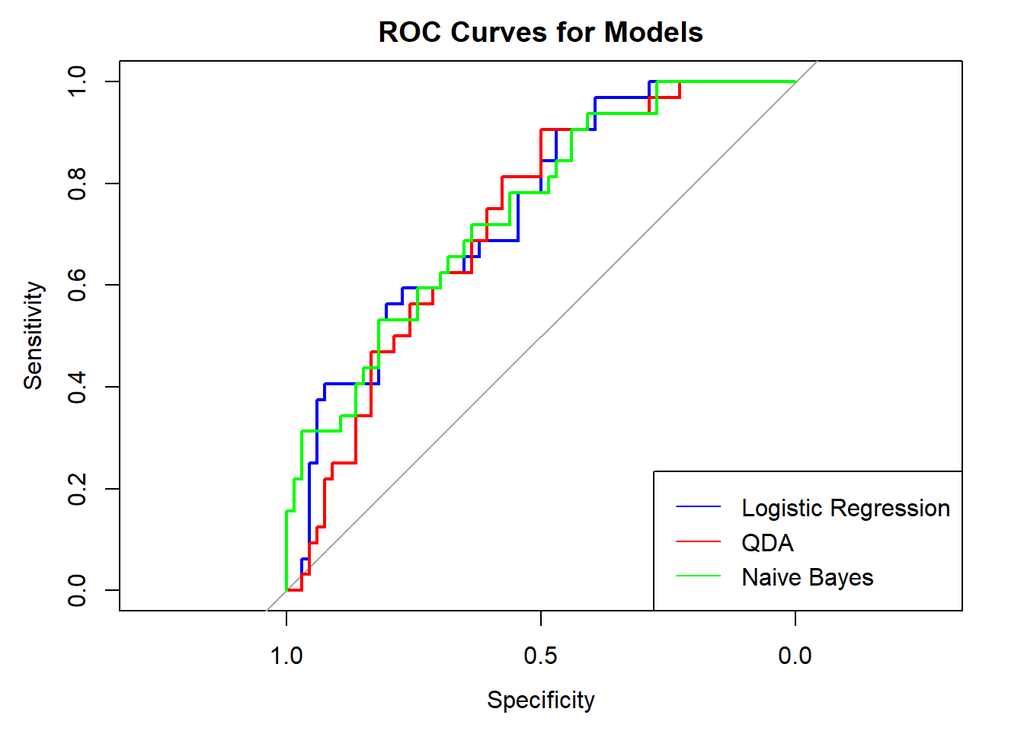

```r
plot(logistic_regresssion_roc, col = "blue", main = "ROC Curves for Models")
lines(QDA_roc, col = "red")
lines(naive_bayes_roc, col = "green")
legend("bottomright", legend = c("Logistic Regression", "QDA", "Naive Bayes"),
       col = c("blue", "red", "green"), lty = 1)
```

```r
# AUC values
auc_logistic <- auc(logistic_regresssion_roc)
auc_qda <- auc(QDA_roc)
auc_nb <- auc(naive_bayes_roc)
cat("AUC Values:\n")
```

```
## AUC Values:
```

```r
cat("Logistic Regression:", auc_logistic, "\nQDA:", auc_qda, "\nNaive Bayes:", auc_nb, "\n")
```

```
## Logistic Regression: 0.7443182
## QDA: 0.7249053
## Naive Bayes: 0.7457386
```

Na podstawie wykresu widać, że model QDA zdaje się gorszy od pozostałych. Na podstawie pola pod wykresem krzywej ROC model naiwnego Bayesa zdaje się być tylko nieco lepszy od regresji logistycznej.